# B-kromatično število in krepki produkt

B-barvanje je pravilno barvanje grafa G za katerega velja, da ima vsaka barva vsaj eno vozlišče, ki ima soseda vseh ostalih barv. B-kromatično število je največje celo število $ \varphi(x)$ za katero ima graf G b-barvanje. Trivialna spodnja meja $ \varphi(x) $ je kromatično število $ \chi (x) $, zgornja meja pa $ \Delta (x) $ + 1.

**Izrek 1:** Naj bo $ v_i \in V(G)$ in $ d(v_1) \geq d(v_2) \geq ... \geq d(v_n)$. Število m(G) = $ max\{ i | d(v_i) \geq i - 1\} $.

Izrek je zelo intuitiven in pravi da za k-b-barvanje potrebujemo vsaj k vozlišč z k - 1 sosedi.

## Krepki produkt

Krepki produkt grafov je binarna operacija $ \boxtimes $ nad dvema grafoma. Vozlišla $ G \boxtimes H $ so vsi pari $ V(G) \times V(H) $. Vozlišči (u, v) in (u', v') v krepkem produktu pa sta sosednji:

```
   u = u' in v je sosednji z v' ali,
   v = v' in u je sosednji z v' ali,
   u je sosednji z u' in v je sosednji z v'.
```

## Spodnja meja

**Izrek 2:** Naj bosta G in H poljubna grafa. Potej je $ \varphi( G \boxtimes H) \geq \varphi(G) * \varphi(H) $.

**Dokaz.** Naj bo $ c_1 \varphi(G)$-b-barvanje grafa G in $ c_2 \varphi(H)$-b-barvanje grafa H. Definirajmo barvanje $c_3$ na grafu $ G \boxtimes H $ kot $$c_3((u, v)) = (c_1(u), c_2(v)) $$.

Očitno je da je barvanje $ c_3 $ pravilno barvanje. Pokazati je treba da je tudi b-barvanje. Naj bo u poljubno vozlišče barve i, ki realizira vse barve v G in v poljubno vozlišče barve j, ki realizira vse barve v H. Barva vozlišča (u, v) v produktu je potem (i, j). Vozlišče (u, v) je sosednje vsem barvam tipa (a, b) kjer a != i in b != j. Ker je u barve i, je vozlišče prav tako sosednje barvam (i, $x_k$) in podobno za v.

## Zgornja meja

B-kromatično število produkta lahko navzgor omejimo s pomočjo trivialne zgornje meje. $$ \varphi( G \boxtimes H) \leq \Delta(G \boxtimes H) + 1 = \Delta(G)\Delta(H) + \Delta(G) + \Delta(H) + 1 $$.

Enakost dobimo če sta b-kromatični števili grafov G in H že zgornji meji. Naj bo $ \varphi( G ) = \Delta(G) + 1 $ in $ \varphi(H) = \Delta(H) + 1 $ potem sledi da je $$ \varphi( G \boxtimes H) = \varphi(G)\varphi(H) $$.

Nasprotna trditev ne drži vedno kar je razvidno npr. iz produkta $ P_5 $ in $ P_3 $.

**Izrek 3:** Naj bo H poljuben graf. Potem je $ \varphi(P_n \boxtimes H) = 3(\Delta(H) + 1) = \varphi(C_n \boxtimes H) $ za vsak $ n \geq 3(\Delta(H) + 1) + 2$.

**Dokaz.** Naj bojo $C_i $ i=1,2,3 skupine barv moči $\Delta(H) + 1$, ki imajo prazen presek. Naj bo u vozlišče maksimalne stopnje v grafu H in $ v_i $ vozlišče v $ P_n $. Poglejmo si vlakna $ H^{v_i} $. Vozlišče z drugo koordinatu u v tem vlaknu ima $ \Delta(H) $ sosedov v vlaknu. Vlakno lahko tako prebarvamo z $ C_1 $. Vlakni $ H^{v_{i-1}} $ in $ H^{v_{i+1}} $ pa lahko prebarvamo z barvami C2 in C3. Pri barvanju posameznega vlakna vozlišče $ v_i $, prebarvamo z i/3-to barvo v ustreznem naboru barv C1, C2 ali C3. Barve v posameznih vlaknih si tako sledijo v zaporedju C1, C2, C3, C1, C2... Ker je u maksimalno vozlišče ima znotraj vlakna $ \Delta{H} $ sosedov razlinčnih barv. Prav tako ima $ \Delta{H} + 1 $ sosedov na vlaknu višje in podobno nižje. Na pozicijah ($v_i$, u) so tako vozliščna sosedna z vsemi barvami. Ker je $ n \geq 3(\Delta(H) + 1) + 2$ je pozicij $(v_i, u)$ dovolj, da se na njih vsaj enkrat pojavi vsaka barva.

Enakost sledi iz zgornje meje v prejšnem odseku, kjer je $ \Delta{G} = 2 $. $ \square $

**Nekaj zgornjih mej**

Spodaj naštete zgornje meje so posledice izreka 3. $$ \varphi(P_n \boxtimes P_1) = 3, n \geq 5$$ $$ \varphi(P_n \boxtimes P_2) = 6, n \geq 8$$ $$ \varphi(P_n \boxtimes P_k) = 9, n \geq 11, k \geq 3$$ $$ \varphi(V_n \boxtimes V_k) = 9, n \geq 11, k \geq 3$$

**Zvezda $K_{1,k}$**

Naj bo $ 1 \leq k \leq \frac{n-5}{3} $. Potem je $$ \varphi(P_n \boxtimes K_{1, k}) = 3(k + 1) = \varphi(C_n \boxtimes K_{1, k}).$$

Rezultat sledi iz izreka 3. Ker mora biti $ n \geq 3(k+1) + 2 $, dobimo da mora biti $ k \leq \frac{n-5}{3} $.

Lahko se vprašamo kaj pa se zgodi pri manjših n-jih.

$$1.) \space \varphi(P_1 \boxtimes K_{1, k}) = 2, k \geq 1$$ $$2.) \space \varphi(P_2 \boxtimes K_{1, k}) = 4, k \geq 1$$

$$3.) \space \varphi(P_3 \boxtimes K_{1, k}) = 4, k = 1$$ $$4.) \space \varphi(P_3 \boxtimes K_{1, k}) = 5, k = 2$$ $$5.)\space \varphi(P_3 \boxtimes K_{1, k}) = 6, k \geq 3$$

$$6.)\space \varphi(P_4 \boxtimes K_{1, k}) = 4, k = 1$$ $$7.) \space \varphi(P_4 \boxtimes K_{1, k}) = 6, k \geq 2$$

$$8.)\space \varphi(P_5 \boxtimes K_{1, k}) = 6, k \geq 1$$ $$9.) \space \varphi(P_n \boxtimes K_{1, k}) = n, k \geq n - 2 \geq 4$$

**Dokaz**

1.) P1 je enota v kreprkem produktu $ \varphi(P_1 \boxtimes K_{1, k}) = \varphi(K_{1, k}) = 2.$  
2.) Je posledica zgornje meje v izreku 1, in trivialne spodnje meje.  
3.) Isto kot 2. 4.) Zgornja meja je 5, spodnja 4. Iz spodnje slike je razvidno, da obstaja 5-b-barvanje.  
6.) Enako kot 2.  
5, 7, 8, 9.) Vsi ti primeri so enaki zgornji meji podani v izerku 1. Zato moramo le pokazati barvanje, ki doseže to mejo.

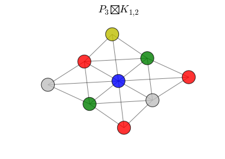

```python
import matplotlib.pyplot as plt
import networkx as nx

P3 = nx.path_graph(3)
G = nx.algorithms.operators.product.strong_product(P3, P3)
pos=nx.spring_layout(G)
nodes = [[(0,0), (1, 2), (2, 0)], [(1,1)], [(0,1), (2, 1)], [(0, 2)], [(1, 0), (2, 2)]]
colors = ["r", "b", "g", "y", "silver"]

for node, color in zip(nodes, colors):
    nx.draw_networkx_nodes(G,pos,
                           nodelist=node,
                           node_color=color,
                           node_size=500,
                       alpha=0.8)

title(r"$ P_3 \boxtimes  K_{1,2} $", fontsize=18)
axis("off")
nx.draw_networkx_edges(G,pos,width=1.0,alpha=0.5)
```

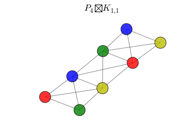

```python
import matplotlib.pyplot as plt
import networkx as nx

P4 = nx.path_graph(4)
star = nx.star_graph(1)
G = nx.algorithms.operators.product.strong_product(P4, star)
pos=nx.spring_layout(G)
nodes = [[(0,0), (2, 0)], [(1,1), (3, 1)], [(0,1), (2, 1)], [(1, 0), (3, 0)]]
colors = ["r", "b", "g", "y"]

for node, color in zip(nodes, colors):
    nx.draw_networkx_nodes(G,pos,
                           nodelist=node,
                           node_color=color,
                           node_size=500,
                       alpha=0.8)

title(r"$ P_4 \boxtimes  K_{1,1} $", fontsize=18)
axis("off")
nx.draw_networkx_edges(G,pos,width=1.0,alpha=0.5)
```

Za primer 5.) bomo pokazali da je b-kromatično število enako zgornji meji. Zapišimo barve vozlišč grafa $ P_3 \boxtimes K_{1, k}, k \geq 3 $ v matriki. Element $a_{ij}$ predstavlja barvo vozlišča (i, j).

$$ \begin{matrix} 1 & 2 & 3 \\ 3 & 4 & 1 \\ 5 & 4 & 6 \\ 6 & 5 & 4 \\ 4 & 6 & 5 \\ .& . & . \\ .& . & . \\ .& . & . \end{matrix} $$

Vsaka vrstica predstavlja vlaken grafa $ P_3 $, stolpec pa vlaken grafa K. Prva vrstica predstvlja vozlišča središča zvezde. Da je barvanje pravilno mora veljati, da se sosednje barve v prvi vrstici razlikujejo. Kot tudi da se v stolpcu i, ne pojavi barva ki se nahaja v prvi vrstici stolpcov i-1, i in i + 1. Dokaz zelo enostavno razširimo na daljše poti.

**Domneva**

Zaključimo lahko z naslednjo domnevo o zgornji meji. Naj bosta G in H poljubna grafa. Potem je

$$ \varphi( G \boxtimes H ) \leq max\{\varphi(G)(\Delta(H) + 1), (\Delta(G) + 1)\varphi(H))\}. $$